# Top 3 IE Comparison

Exercise

# Loading Packages and the Dataset

```r
library(tidyverse)
library(rvest)

top_3_IE <- readRDS("C:/Users/fatma/Downloads/top_3_IE.rds")
```

# Data Analysis

## Preferred University Analysis

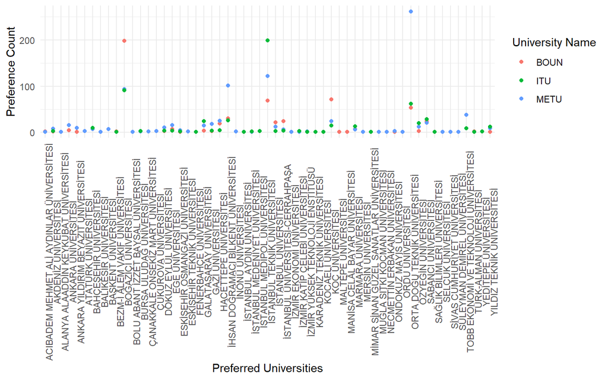

```r
##Preferred univ analysis

df_uni_boun<-top_3_IE$univ_prefs$BOUN
df_uni_itu<-top_3_IE$univ_prefs$ITU
df_uni_metu<-top_3_IE$univ_prefs$METU
uni_metu_boun<-full_join(df_uni_boun,df_uni_metu)
joined_all_uni<-full_join(uni_metu_boun,df_uni_itu)
joined_all_uni$preference_count<-as.numeric(joined_all_uni$preference_count)
joined_all_uni%>%
  ggplot(.,aes(x=preferred_univ,y=preference_count,color=univ_name))+
  geom_point()+
  labs(x="Preferred Universities", y="Preference Count", color="University Name")+
  theme_minimal()+
  theme(axis.text.x = element_text(angle=90))
```

Students in all three universities prefer their own university at most. Koc University and Istanbul Technical University are the other most popular universities for BOUN students before coming to BOUN. For the students in ITU, BOUN and METU are the other most popular ones considering all the universities preferred. For students in METU, Bilkent and ITU are the other most popular ones in their preference lists before coming to METU. So, ITU is in the most popular universities list of other two university and ITU’s list also contains BOUN and METU. However, METU and BOUN does not contain each other. Instead, the students prefer universities whose type are foundation such as Koc and Bilkent.

## Preferred City Analysis

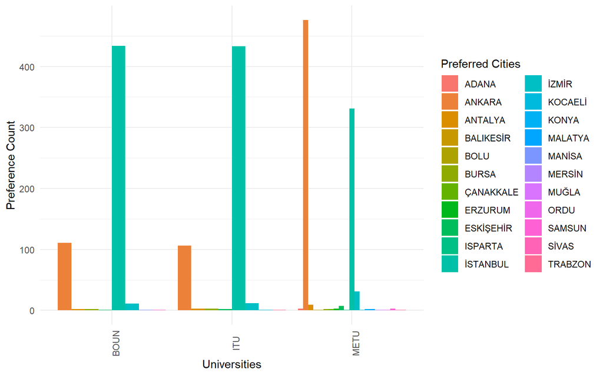

```r
#Preferred City analysis

df_city_boun<-top_3_IE$city_prefs$BOUN
df_city_itu<-top_3_IE$city_prefs$ITU
df_city_metu<-top_3_IE$city_prefs$METU
city_metu_boun<-full_join(df_city_boun,df_city_metu)
joined_all_city<-full_join(city_metu_boun,df_city_itu)
joined_all_city$preference_count<-as.numeric(joined_all_city$preference_count)
joined_all_city%>%
  ggplot(.,aes(x=univ_name,y=preference_count,fill=preferred_city))+
  geom_col(position="dodge")+
  labs(x="Universities", y="Preference Count", fill="Preferred Cities")+
  theme_minimal()+
  theme(axis.text.x = element_text(angle=90))
```

Istanbul, Ankara and Izmir are the most popular 3 cities for each university. However, students in METU prefer Ankara most unlike students in BOUN and ITU.

## Preferred Program Analysis

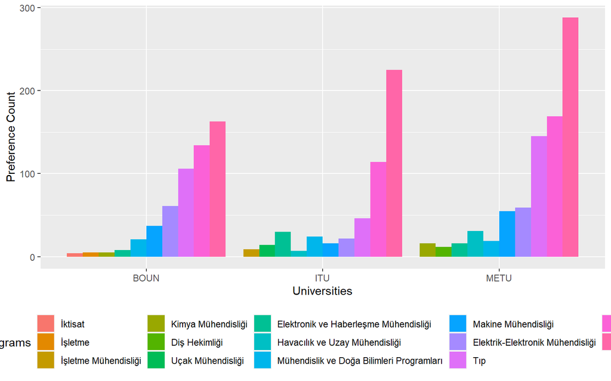

```r
#Preferred Program analysis

df_prog_boun<-top_3_IE$prog_prefs$BOUN
df_prog_boun<-df_prog_boun%>%
  arrange(desc(preference_count))%>%
  head(10)

df_prog_itu<-top_3_IE$prog_prefs$ITU
df_prog_itu<-df_prog_itu%>%
arrange(desc(preference_count))%>%
  head(10)

df_prog_metu<-top_3_IE$prog_prefs$METU
df_prog_metu<-df_prog_metu%>%
arrange(desc(preference_count))%>%
  head(10)

prog_metu_boun<-full_join(df_prog_boun,df_prog_metu)
joined_all_prog<-full_join(prog_metu_boun,df_prog_itu)
joined_all_prog$preference_count<-as.numeric(joined_all_prog$preference_count)
joined_all_prog%>%
  ggplot(.,aes(x=univ_name,y=preference_count,fill=reorder(preferred_program,preference_count)))+
  geom_col(position="dodge")+
  theme(legend.position = "bottom")+
  labs(x="Universities", y="Preference Count", fill="Preferred Programs")
```

Industrial engineering students prefer their department most in each university. Also, the first 7 preferences are the same for all. However,

- Students in BOUN does not prefer Dentistry
- Students in ITU does not prefer Chemical Engineering
- Only students in ITU prefer Management Engineering
- Only students in BOUN prefer Management and Economics

in their top 10 lists.